# 03_analysis

## 第四部分：描述性统计与可视化

4.1 基本统计量  
说明  
本部分需计算 10 只股票日对数收益率的核心统计指标，包括年化均值、年化波动率、偏度、峰度、最大回撤。关键步骤：

计算日对数收益率：(r_t = \ln(P_t / P_{t-1}))；  
年化均值：日均值 × 252（年交易日数）；  
年化波动率：日波动率 × √252；  
偏度 / 峰度：衡量收益率分布的非正态性；  
最大回撤：某一时间段内从峰值到谷值的最大跌幅。

```python
# ================== 4.1 描述性统计 ==================
import pandas as pd
import numpy as np
import warnings
import os
warnings.filterwarnings('ignore')
os.makedirs("output", exist_ok=True)

df = pd.read_csv("data/clean/stock_clean.csv", parse_dates=["日期"])

df_list = []
for code in df["code"].unique():
    temp = df[df["code"] == code].copy().sort_values("日期")
    temp["log_return"] = np.log(temp["收盘"] / temp["收盘"].shift(1))
    df_list.append(temp)
df = pd.concat(df_list, ignore_index=True)

def calc_stats(series):
    mu = series.mean()
    vol = series.std()
    skew = series.skew()
    kurt = series.kurtosis()
    ann_ret = mu * 252
    ann_vol = vol * np.sqrt(252)
    cum = (1 + series).cumprod()
    peak = cum.cummax()
    dd = (cum / peak) - 1
    max_dd = dd.min()
    return pd.Series([ann_ret, ann_vol, skew, kurt, max_dd],
                     index=["年化收益率", "年化波动率", "偏度", "峰度", "最大回撤"])

stats = df.dropna(subset=["log_return"]).groupby("code")["log_return"].apply(calc_stats).reset_index()
stats["code_str"] = stats["code"].astype(str).str.lstrip("0")

stock_info = pd.DataFrame([
    ["600036", "银行"],["601398", "银行"],["600660", "汽车制造"],
    ["600104", "汽车"],["600900", "电力"],["601088", "能源"],
    ["600941", "通信"],["601728", "通信"],["601006", "交通运输"],["2352", "物流"]
], columns=["code_str", "行业"])

stats = stats.merge(stock_info, on="code_str", how="left")
stats = stats.round(4)
print("=== 4.1 股票收益率描述性统计 ===")
print(stats)
stats.to_csv("output/descriptive_stats.csv", index=False, encoding="utf-8-sig")
```

```
=== 4.1 股票收益率描述性统计 ===
      code level_1  log_return code_str    行业
0     2352   年化收益率      0.0071     2352    物流
1     2352   年化波动率      0.3218     2352    物流
2     2352      偏度      0.3819     2352    物流
3     2352      峰度      3.6328     2352    物流
4     2352    最大回撤     -0.7567     2352    物流
5   600036   年化收益率      0.0380   600036    银行
6   600036   年化波动率      0.2753   600036    银行
7   600036      偏度      0.2697   600036    银行
8   600036      峰度      3.2220   600036    银行
9   600036    最大回撤     -0.5464   600036    银行
10  600104   年化收益率     -0.0798   600104    汽车
11  600104   年化波动率      0.3148   600104    汽车
12  600104      偏度      0.3482   600104    汽车
```

[output cut: 37 more lines]

## 任务 4.2：归一化收盘价走势图

说明  
以首日价格 = 1 做归一化  
对比所有股票走势  
按行业区分颜色  
自动保存高清图

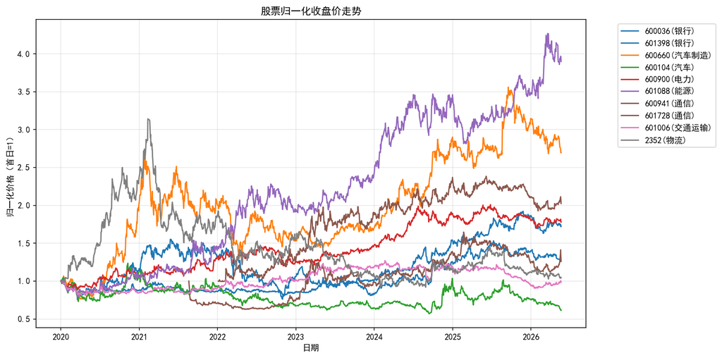

```python
# ================== 4.2 归一化收盘价走势图 ==================
import matplotlib.pyplot as plt
import pandas as pd
import os
os.makedirs("output", exist_ok=True)

plt.rcParams['font.sans-serif'] = ['SimHei']
plt.rcParams['axes.unicode_minus'] = False
plt.rcParams['figure.dpi'] = 150

df = pd.read_csv("data/clean/stock_clean.csv", parse_dates=["日期"])
df["code_str"] = df["code"].astype(str).str.lstrip("0")

stock_info = {
    "600036":"银行","601398":"银行","600660":"汽车制造",
    "600104":"汽车","600900":"电力","601088":"能源",
    "600941":"通信","601728":"通信","601006":"交通运输","2352":"物流"
}
color_map = {
    "银行":"#1f77b4","汽车制造":"#ff7f0e","汽车":"#2ca02c",
    "电力":"#d62728","能源":"#9467bd","通信":"#8c564b",
    "交通运输":"#e377c2","物流":"#7f7f7f"
}

df["norm"] = df.groupby("code")["收盘"].transform(lambda x: x / x.iloc[0])

plt.figure(figsize=(12,6))
for code in df["code"].unique():
    sub = df[df["code"] == code]
    c_str = str(code).lstrip("0")
    plt.plot(sub["日期"], sub["norm"], label=f"{code}({stock_info[c_str]})", color=color_map[stock_info[c_str]])

plt.title("股票归一化收盘价走势")
plt.xlabel("日期")
plt.ylabel("归一化价格（首日=1）")
plt.legend(bbox_to_anchor=(1.05,1), loc="upper left")
plt.grid(alpha=0.3)
plt.tight_layout()
plt.savefig("output/plot_norm_price.png", dpi=150, bbox_inches="tight")
plt.show()
```

## 任务 4.3：收益率分布直方图（分面图）

说明  
2 行 5 列展示 10 只股票收益率分布  
叠加正态分布曲线  
直观观察尖峰厚尾

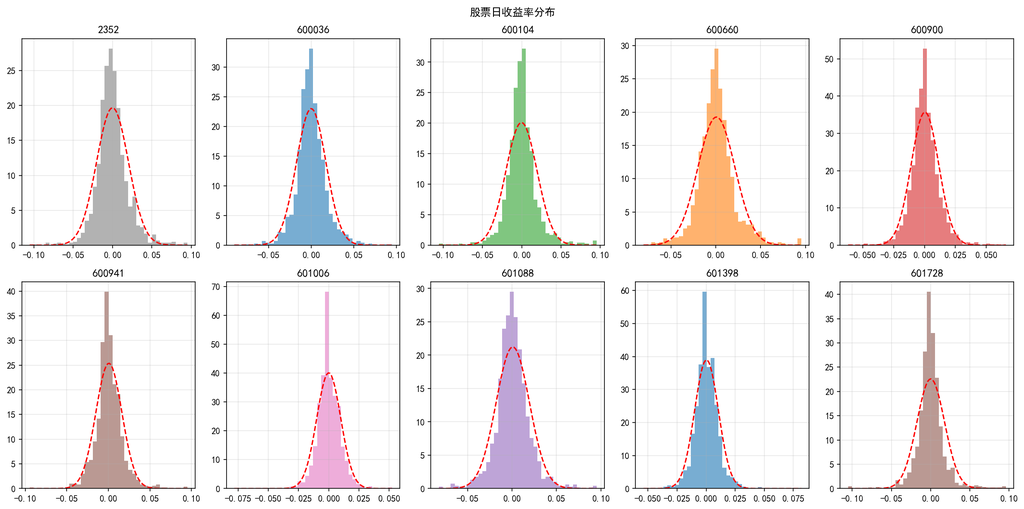

```python
# ================== 4.3 收益率分布 ==================
import matplotlib.pyplot as plt
from scipy.stats import norm
import numpy as np
import pandas as pd
import os
os.makedirs("output", exist_ok=True)

plt.rcParams['font.sans-serif'] = ['SimHei']
plt.rcParams['axes.unicode_minus'] = False
plt.rcParams['figure.dpi'] = 150

df = pd.read_csv("data/clean/stock_clean.csv", parse_dates=["日期"])
df_list = []
for code in df["code"].unique():
    temp = df[df["code"] == code].copy().sort_values("日期")
    temp["log_return"] = np.log(temp["收盘"] / temp["收盘"].shift(1))
    df_list.append(temp)
df = pd.concat(df_list, ignore_index=True)
df_ret = df.dropna(subset=["log_return"])

stock_info = {
    "600036":"银行","601398":"银行","600660":"汽车制造",
    "600104":"汽车","600900":"电力","601088":"能源",
    "600941":"通信","601728":"通信","601006":"交通运输","2352":"物流"
}
color_map = {
    "银行":"#1f77b4","汽车制造":"#ff7f0e","汽车":"#2ca02c",
    "电力":"#d62728","能源":"#9467bd","通信":"#8c564b",
    "交通运输":"#e377c2","物流":"#7f7f7f"
}

codes = sorted(df_ret["code"].unique())
fig, axes = plt.subplots(2,5,figsize=(16,8))
axes = axes.flatten()

for i, code in enumerate(codes):
    sub = df_ret[df_ret["code"] == code]
    c_str = str(code).lstrip("0")
    r = sub["log_return"]
    mu, sig = r.mean(), r.std()
    axes[i].hist(r, bins=40, density=True, alpha=0.6, color=color_map[stock_info[c_str]])
    x = np.linspace(r.min(), r.max(), 100)
    axes[i].plot(x, norm.pdf(x, mu, sig), "r--")
    axes[i].set_title(f"{code}")
    axes[i].grid(alpha=0.3)

plt.suptitle("股票日收益率分布")
plt.tight_layout()
plt.savefig("output/plot_return_dist.png", dpi=150)
plt.show()
```

## 任务 4.4：收益率相关系数热力图

说明  
计算股票间收益率相关性  
热力图展示行业内高度相关  
自动保存高清图

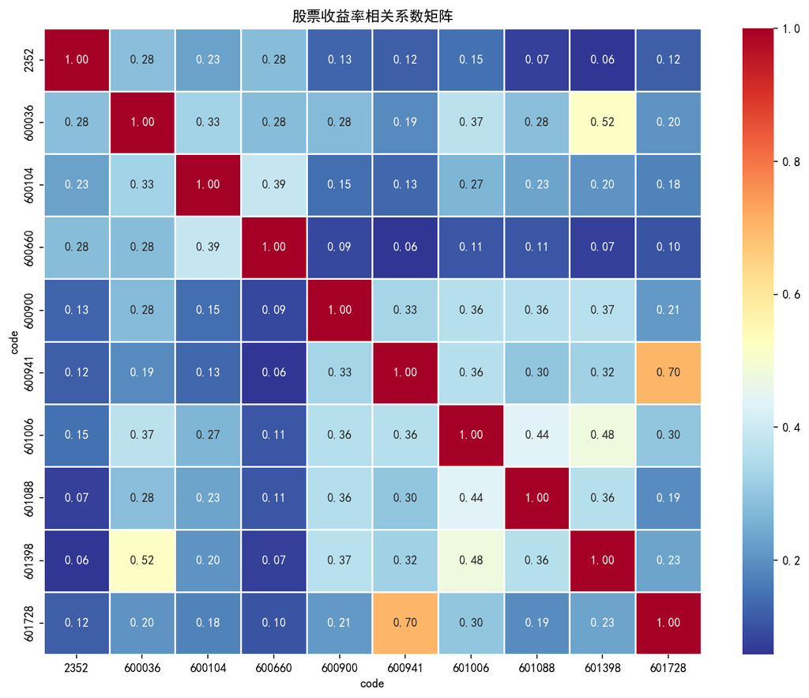

```python
# ================== 4.4 相关系数热力图 ==================
import seaborn as sns
import matplotlib.pyplot as plt
import pandas as pd
import numpy as np
import os
os.makedirs("output", exist_ok=True)

plt.rcParams['font.sans-serif'] = ['SimHei']
plt.rcParams['axes.unicode_minus'] = False
plt.rcParams['figure.dpi'] = 150

df = pd.read_csv("data/clean/stock_clean.csv", parse_dates=["日期"])
df_list = []
for code in df["code"].unique():
    temp = df[df["code"] == code].copy().sort_values("日期")
    temp["log_return"] = np.log(temp["收盘"] / temp["收盘"].shift(1))
    df_list.append(temp)
df = pd.concat(df_list, ignore_index=True)

wide = df.pivot(index="日期", columns="code", values="log_return")
corr = wide.corr()

plt.figure(figsize=(10,8))
sns.heatmap(corr, annot=True, cmap="RdYlBu_r", fmt=".2f", linewidths=0.5)
plt.title("股票收益率相关系数矩阵")
plt.tight_layout()
plt.savefig("output/plot_corr_heatmap.png", dpi=150)
plt.show()
```

## 任务 4.5：宏观指标（CPI）与指数走势对比

说明  
读取 CPI 月度数据  
与中证 500 指数对比  
观察宏观与股市联动

[figure not shown]

```python
# ================== 4.5 宏观指标与指数对比 ==================
import pandas as pd
import matplotlib.pyplot as plt
import os
os.makedirs("output", exist_ok=True)

plt.rcParams['font.sans-serif'] = ['SimHei']
plt.rcParams['axes.unicode_minus'] = False
plt.rcParams['figure.dpi'] = 150

idx = pd.read_parquet("data/index/000905.parquet").dropna()
cpi = pd.read_parquet("data/macro/cpi_monthly.parquet").dropna()

fig, ax1 = plt.subplots(figsize=(12,5))
ax1.plot(idx["日期"], idx["收盘"], label="中证500收盘价", color="#1f77b4")
ax1.set_ylabel("指数收盘价")
ax1.legend(loc="upper left")

ax2 = ax1.twinx()
ax2.plot(cpi["日期"], cpi.iloc[:,1], label="CPI", color="red", linestyle="--")
ax2.set_ylabel("CPI")
ax2.legend(loc="upper right")

plt.title("中证500 vs CPI")
plt.grid(alpha=0.3)
plt.tight_layout()
plt.savefig("output/plot_macro_index.png", dpi=150)
plt.show()
```

## 第五部分：回归分析

```
===== CAPM结果 =====
     股票代码    行业         α     α_p      β     β下     β上     R²
0  002352    物流 -0.000175  0.7095  0.611  0.544  0.678  0.173
1  600036    银行 -0.000027  0.9477  0.428  0.369  0.487  0.116
2  600104    汽车 -0.000528  0.2452  0.633  0.568  0.697  0.193
3  600660  汽车制造  0.000439  0.3651  0.596  0.527  0.665  0.157
4  600900    电力  0.000277  0.3319  0.083  0.042  0.123  0.010
5  600941    通信  0.000578  0.2292  0.140  0.073  0.208  0.016
6  601006  交通运输 -0.000129  0.5980  0.191  0.156  0.226  0.070
7  601088    能源  0.000765  0.1064  0.253  0.185  0.320  0.034
8  601398    银行  0.000264  0.3111  0.034 -0.003  0.071  0.002
9  601728    通信  0.000193  0.7012  0.270  0.197  0.342  0.045
```

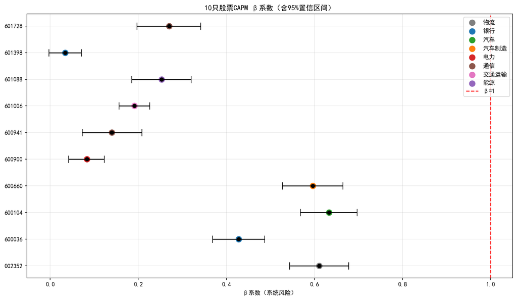

```
===== 结果分析 =====
β>1：[]，风险高于大盘
α显著(p<0.05)：[]，存在超额收益
```

```python
# 第五部分 5.1 CAPM回归（极简稳定版）
import pandas as pd
import numpy as np
import statsmodels.api as sm
import matplotlib.pyplot as plt
import warnings
import os
warnings.filterwarnings('ignore')
os.makedirs("output", exist_ok=True)

plt.rcParams['font.sans-serif'] = ['SimHei']
plt.rcParams['axes.unicode_minus'] = False
plt.rcParams['figure.dpi'] = 150

# 1. 读取+清洗，强制数值
df_stock = pd.read_csv("data/clean/stock_clean.csv", parse_dates=["日期"])
df_stock["code"] = df_stock["code"].astype(str).str.zfill(6)
df_stock["收盘"] = pd.to_numeric(df_stock["收盘"], errors="coerce")
df_stock = df_stock.dropna()

df_idx = pd.read_parquet("data/index/000905.parquet")
df_idx["收盘"] = pd.to_numeric(df_idx["收盘"], errors="coerce")
df_idx = df_idx.dropna().sort_values("日期")

# 2. 安全计算收益率
def safe_ret(x):
    x = x.dropna()
    return np.log(x / x.shift(1))

df_list = []
for code in df_stock["code"].unique():
    temp = df_stock[df_stock["code"]==code].copy().sort_values("日期")
    temp["ret"] = safe_ret(temp["收盘"])
    df_list.append(temp)
df_stock = pd.concat(df_list, ignore_index=True)
df_idx["mkt_ret"] = safe_ret(df_idx["收盘"])

# 3. 合并+超额收益
df_merge = pd.merge(df_stock, df_idx[["日期","mkt_ret"]], on="日期")
df_merge = df_merge.dropna()
rf = 0.02 / 252
df_merge["er"] = df_merge["ret"] - rf
df_merge["em"] = df_merge["mkt_ret"] - rf

# 4. 行业映射（6位字符串）
industry = {
    "600036":"银行","601398":"银行","600660":"汽车制造",
    "600104":"汽车","600900":"电力","601088":"能源",
    "600941":"通信","601728":"通信","601006":"交通运输","002352":"物流"
}

# 5. CAPM回归
res = []
for code in sorted(df_merge["code"].unique()):
    d = df_merge[df_merge["code"]==code]
    y = d["er"]
    X = sm.add_constant(d["em"])
    m = sm.OLS(y,X).fit()
    res.append({
        "股票代码":code,"行业":industry[code],
        "α":round(m.params.const,6),"α_p":round(m.pvalues.const,4),
        "β":round(m.params.em,3),
        "β下":round(m.conf_int().loc["em",0],3),
        "β上":round(m.conf_int().loc["em",1],3),
        "R²":round(m.rsquared,3)
    })
capm_df = pd.DataFrame(res)
print("===== CAPM结果 =====")
print(capm_df)
capm_df.to_csv("output/capm_result.csv", index=False, encoding="utf-8-sig")

# 6. 绘图
fig,ax=plt.subplots(figsize=(12,7))
y_pos=np.arange(len(capm_df))
x=capm_df["β"]
err=[x-capm_df["β下"], capm_df["β上"]-x]
ax.errorbar(x,y_pos,xerr=err,fmt="o",capsize=6,c="k")
cmap={"银行":"#1f77b4","汽车制造":"#ff7f0e","汽车":"#2ca02c","电力":"#d62728","能源":"#9467bd","通信":"#8c564b","交通运输":"#e377c2","物流":"#7f7f7f"}
for i,row in capm_df.iterrows():
    ax.scatter(row["β"],i,c=cmap[row["行业"]],s=90,label=row["行业"] if row["行业"] not in ax.get_legend_handles_labels()[1] else "")
ax.axvline(1,c="r",ls="--",label="β=1")
ax.set_yticks(y_pos)
ax.set_yticklabels(capm_df["股票代码"])
ax.set_xlabel("β系数（系统风险）")
ax.set_title("10只股票CAPM β系数（含95%置信区间）")
ax.legend(loc="upper right")
ax.grid(alpha=0.3)
plt.tight_layout()
plt.savefig("output/capm_beta.png",dpi=150,bbox_inches="tight")
plt.show()

# 7. 分析
print("\n===== 结果分析 =====")
print(f"β>1：{capm_df[capm_df['β']>1]['股票代码'].tolist()}，风险高于大盘")
print(f"α显著(p<0.05)：{capm_df[capm_df['α_p']<0.05]['股票代码'].tolist()}，存在超额收益")
```

5.1 CAPM 模型估计 分析讨论